# Linear Regression course project

jbassard

27 july 2017

# Executive Summary

This is the course project for the statistical inference class on coursera. In this report, we will examine the “mtcars” dataset and explore how miles per gallon (MPG) is affected by automatic or manual transmission. In particularly, we have to answer the two questions: + Is an automatic or manual transmission better for MPG? + Quantify the MPG difference between automatic and manual transmissions.

### Loading necessary packages and dataset

```r
if (!require("knitr")) {
    install.packages("knitr")}
data(mtcars) #Loading the dataset
library(knitr)
```

### Setting the default of echo and cache to be True throughout the whole report

```r
knitr::opts_chunk$set(echo = TRUE) #Make the code always visible
knitr::opts_chunk$set(cache=TRUE)
```

# Data Description

The data was extracted from the 1974 Motor Trend US magazine, and comprises fuel consumption and 10 aspects of automobile design and performance for 32 automobiles (1973-74 models).We use regression models and exploratory data analyses to mainly explore how automatic (am = 0) and manual (am = 1) transmissions features affect the MPG feature.

A data frame with 32 observations on 11 variables.

[, 1] mpg Miles/(US) gallon [, 2] cyl Number of cylinders [, 3] disp Displacement (cu.in.) [, 4] hp Gross horsepower [, 5] drat Rear axle ratio [, 6] wt Weight (1000 lbs) [, 7] qsec 1/4 mile time [, 8] vs V/S [, 9] am Transmission (0 = automatic, 1 = manual) [,10] gear Number of forward gears [,11] carb Number of carburetors.

# Data Cleaning and Exploration

```r
dim(mtcars)
```

```
## [1] 32 11
```

```r
str(mtcars)
```

```
## 'data.frame':    32 obs. of  11 variables:
##  $ mpg : num  21 21 22.8 21.4 18.7 18.1 14.3 24.4 22.8 19.2 ...
##  $ cyl : num  6 6 4 6 8 6 8 4 4 6 ...
##  $ disp: num  160 160 108 258 360 ...
##  $ hp  : num  110 110 93 110 175 105 245 62 95 123 ...
##  $ drat: num  3.9 3.9 3.85 3.08 3.15 2.76 3.21 3.69 3.92 3.92 ...
##  $ wt  : num  2.62 2.88 2.32 3.21 3.44 ...
##  $ qsec: num  16.5 17 18.6 19.4 17 ...
##  $ vs  : num  0 0 1 1 0 1 0 1 1 1 ...
##  $ am  : num  1 1 1 0 0 0 0 0 0 0 ...
##  $ gear: num  4 4 4 3 3 3 3 4 4 4 ...
##  $ carb: num  4 4 1 1 2 1 4 2 2 4 ...
```

```r
head(mtcars, 15)
```

```
##                     mpg cyl  disp  hp drat    wt  qsec vs am gear carb
## Mazda RX4          21.0   6 160.0 110 3.90 2.620 16.46  0  1    4    4
## Mazda RX4 Wag      21.0   6 160.0 110 3.90 2.875 17.02  0  1    4    4
## Datsun 710         22.8   4 108.0  93 3.85 2.320 18.61  1  1    4    1
## Hornet 4 Drive     21.4   6 258.0 110 3.08 3.215 19.44  1  0    3    1
## Hornet Sportabout  18.7   8 360.0 175 3.15 3.440 17.02  0  0    3    2
## Valiant            18.1   6 225.0 105 2.76 3.460 20.22  1  0    3    1
## Duster 360         14.3   8 360.0 245 3.21 3.570 15.84  0  0    3    4
## Merc 240D          24.4   4 146.7  62 3.69 3.190 20.00  1  0    4    2
## Merc 230           22.8   4 140.8  95 3.92 3.150 22.90  1  0    4    2
## Merc 280           19.2   6 167.6 123 3.92 3.440 18.30  1  0    4    4
## Merc 280C          17.8   6 167.6 123 3.92 3.440 18.90  1  0    4    4
## Merc 450SE         16.4   8 275.8 180 3.07 4.070 17.40  0  0    3    3
## Merc 450SL         17.3   8 275.8 180 3.07 3.730 17.60  0  0    3    3
## Merc 450SLC        15.2   8 275.8 180 3.07 3.780 18.00  0  0    3    3
## Cadillac Fleetwood 10.4   8 472.0 205 2.93 5.250 17.98  0  0    3    4
```

```r
mtcars$am <- factor(mtcars$am, labels=c("Automatic","Manual")) # for better readibility, O and 1 are renamed: 0=automatic, 1=manual
```

Boxplot of MPG vs. Transmission.

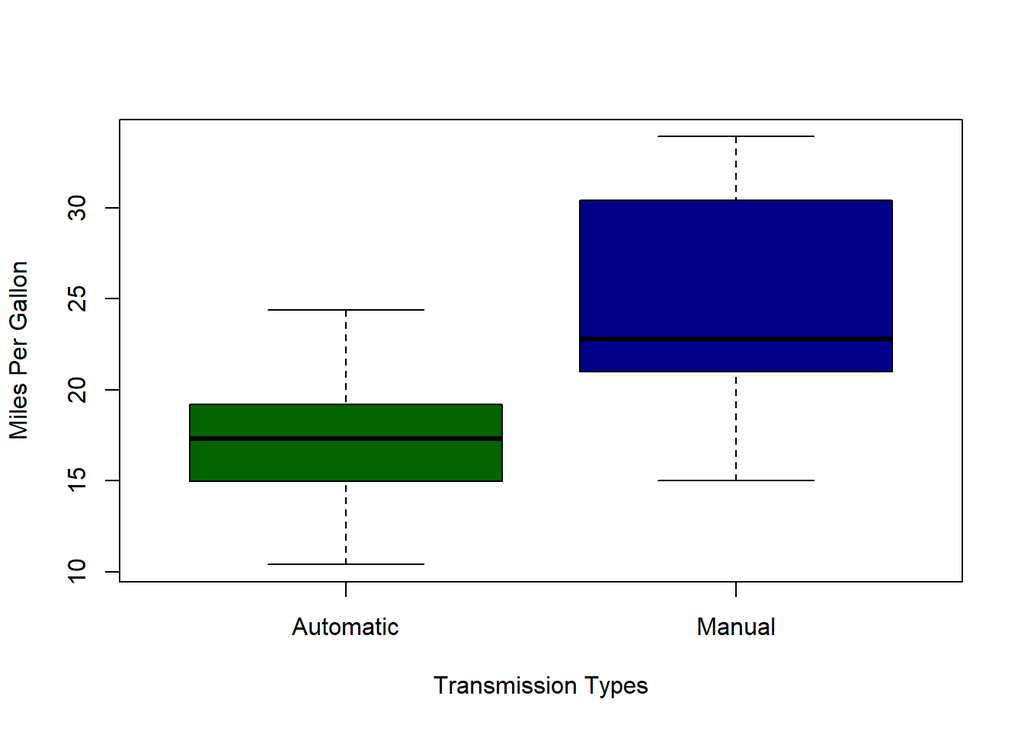

```r
boxplot(mpg ~ am, data = mtcars, col = (c("dark green","dark blue")), ylab = "Miles Per Gallon", xlab = "Transmission Types") #Display a quick and dirty graph for the data
```

From the boxplot, it seems there is an impact of the transmission type on MPG with Automatic transmission having a lower MPG.

# Inference

We set the null hypothesis as the MPG of the Automatic and Manual transmissions has no difference. We use the two sample T-test to test the hypothesis.

```r
inference <- t.test(mpg ~ am, data=mtcars)
inference$p.value
```

```
## [1] 0.001373638
```

```r
inference$estimate
```

```
## mean in group Automatic    mean in group Manual
##                17.14737                24.39231
```

# Linear regression models

## Simple linear regression model

Now to quantify the difference confirmed by the T.test, we will do a linear regression. We will use MPG as the dependent variable and AM as the independent variable to fit a linear regression.

```r
LinReg <- lm(mpg ~ am, data=mtcars)
summary(LinReg)
```

```
##
## Call:
## lm(formula = mpg ~ am, data = mtcars)
##
## Residuals:
##     Min      1Q  Median      3Q     Max
## -9.3923 -3.0923 -0.2974  3.2439  9.5077
##
## Coefficients:
##             Estimate Std. Error t value Pr(>|t|)
## (Intercept)   17.147      1.125  15.247 1.13e-15 ***
## amManual       7.245      1.764   4.106 0.000285 ***
## ---
## Signif. codes:  0 '***' 0.001 '**' 0.01 '*' 0.05 '.' 0.1 ' ' 1
##
## Residual standard error: 4.902 on 30 degrees of freedom
## Multiple R-squared:  0.3598, Adjusted R-squared:  0.3385
## F-statistic: 16.86 on 1 and 30 DF,  p-value: 0.000285
```

Since the p-value = 0.000285 is less than 0.05 so we rejected null hypothesis. We have a significant difference. Looking at the coefficien, we see again the difference of 7.245 miles per gallon at the advantage of the manual cars. But the adjusted R squared value is 0.3385 which means our model only explains 33.85% of the variance. Thus, we need to include other predictors in the linear regression, we need to build a multivariate linear regression.

## Multivariate linear regression model

The new model will use other variables to make it more accurate. We run an analysis of variance to find the variables to add.

```r
AOV <- aov(mpg ~ ., data = mtcars)
summary(AOV)
```

[output not shown]

```r
multivar <- lm(mpg ~ am + cyl + disp + wt, data = mtcars)
summary(multivar)
```

[output not shown]

## Residual Analysis and Diagnostics

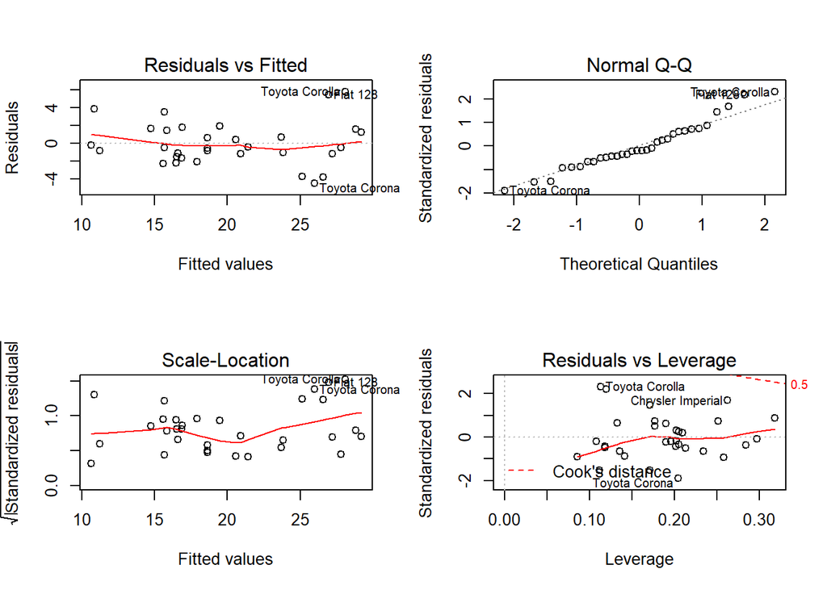

```r
par(mfrow = c(2,2))
plot(multivar)
```

The “Residuals vs Fitted” plot here shows us that there is no patterns in the residuals from the Multivariate model. We can also see that they are normally distributed (normal Q-Q plot), with the exception of a few outliers.

# Conclusion

**Is an automatic or manual transmission better for MPG?** It appears that manual transmission cars are better for MPG compared to automatic cars. However when modeled with confounding variables like cyl, disp and wt, the difference is not as significant as it seems in the beginning. In fact, a big part of the difference is explained by other variables.